# FinalProjectData

Lily Jakielaszek, Allison Denenberg, Ayoolwatomiwa Ogunrombi

### Load the Libraries and Datasets

```r
# front matter
rm(list = ls())
library(DataComputing)
library(lubridate)
library(tidyverse)
library(rvest)
library(mosaic)
library(party)
OccupationProjection <- read.csv("https://query.data.world/s/hfgf3loqzzbk34aytghvne5sxg3ljr", header=TRUE, stringsAsFactors=FALSE);
OccupationProjection<-OccupationProjection%>%
  filter(Occupation.Name!="Total, All Occupations")
salaries_by_region = readr::read_csv("salaries-by-region.csv")
salaries_by_college_type = readr::read_csv("salaries-by-college-type.csv")
degrees_that_pay_back = readr::read_csv("degrees-that-pay-back.csv")
```

# Research Question

Which schools, majors, and occupations have the highest median salary? This question can act as a game plan for prospective college students.

## Make New Datasets

These datasets will be the ones that will be used to perform statistics on. They are renamed from the original datasets and include all the same information except they have R acceptable variable names and the correct type for the their output.

```r
SalariesByRegion <-
  salaries_by_region %>%
  mutate(School_Name = `School Name`,
         Mid_Career_Median_Salary = as.numeric(gsub('\\$|,', '', `Mid-Career Median Salary`)),
         Starting_Median_Salary = as.numeric(gsub('\\$|,', '', `Starting Median Salary`)),
         Mid_Career_10th_Percentile_Salary = as.numeric(gsub('\\$|,', '', `Mid-Career 10th Percentile Salary`)),
         Mid_Career_25th_Percentile_Salary = as.numeric(gsub('\\$|,', '', `Mid-Career 25th Percentile Salary`)),
         Mid_Career_75th_Percentile_Salary = as.numeric(gsub('\\$|,', '', `Mid-Career 75th Percentile Salary`)),
         Mid_Career_90th_Percentile_Salary = as.numeric(gsub('\\$|,', '', `Mid-Career 90th Percentile Salary`)),
         Difference = Mid_Career_Median_Salary - Starting_Median_Salary)
```

```
NAs introduced by coercionNAs introduced by coercion
```

```r
SalariesByRegion <-
  SalariesByRegion %>%
  select(School_Name, Region, Mid_Career_Median_Salary, Starting_Median_Salary, Mid_Career_10th_Percentile_Salary, Mid_Career_25th_Percentile_Salary, Mid_Career_75th_Percentile_Salary, Mid_Career_90th_Percentile_Salary, Difference)
SalariesByRegion
```

| School_Name | Region | Mid_Career_Median_Salary | Starting_Median_Salary | Mid_Career_10th_Percentile_Salary | Mid_Career_25th_Percentile_Salary | Mid_Career_75th_Percentile_Salary | Mid_Career_90th_Percentile_Salary | Difference |
| --- | --- | --- | --- | --- | --- | --- | --- | --- |
| Stanford University | California | 129000 | 70400 | 68400 | 93100 | 184000 | 257000 | 58600 |
| California Institute of Technology (CIT) | California | 123000 | 75500 | NA | 104000 | 161000 | NA | 47500 |
| Harvey Mudd College | California | 122000 | 71800 | NA | 96000 | 180000 | NA | 50200 |
| University of California, Berkeley | California | 112000 | 59900 | 59500 | 81000 | 149000 | 201000 | 52100 |
| Occidental College | California | 105000 | 51900 | NA | 54800 | 157000 | NA | 53100 |
| Cal Poly San Luis Obispo | California | 101000 | 57200 | 55000 | 74700 | 133000 | 178000 | 43800 |
| University of California at Los Angeles (UCLA) | California | 101000 | 52600 | 51300 | 72500 | 139000 | 193000 | 48400 |
| University of California, San Diego (UCSD) | California | 101000 | 51100 | 51700 | 75400 | 131000 | 177000 | 49900 |
| Pomona College | California | 101000 | 48600 | NA | 63300 | 161000 | NA | 52400 |
| University of Southern California (USC) | California | 99600 | 54800 | 49700 | 73800 | 140000 | 201000 | 44800 |

[output cut: 310 more lines]

```r
SalariesByCollegeType <-
  salaries_by_college_type %>%
  mutate(School_Name = `School Name`,
         School_Type = `School Type`,
         Mid_Career_Median_Salary = as.numeric(gsub('\\$|,', '', `Mid-Career Median Salary`)),
         Starting_Median_Salary = as.numeric(gsub('\\$|,', '', `Starting Median Salary`)),
         Mid_Career_10th_Percentile_Salary = as.numeric(gsub('\\$|,', '', `Mid-Career 10th Percentile Salary`)),
         Mid_Career_25th_Percentile_Salary = as.numeric(gsub('\\$|,', '', `Mid-Career 25th Percentile Salary`)),
         Mid_Career_75th_Percentile_Salary = as.numeric(gsub('\\$|,', '', `Mid-Career 75th Percentile Salary`)),
         Mid_Career_90th_Percentile_Salary = as.numeric(gsub('\\$|,', '', `Mid-Career 90th Percentile Salary`)),
         Difference = Mid_Career_Median_Salary - Starting_Median_Salary)
```

```
NAs introduced by coercionNAs introduced by coercion
```

```r
SalariesByCollegeType <-
  SalariesByCollegeType %>%
  select(School_Name, School_Type, Starting_Median_Salary, Mid_Career_Median_Salary, Mid_Career_10th_Percentile_Salary, Mid_Career_25th_Percentile_Salary, Mid_Career_75th_Percentile_Salary, Mid_Career_90th_Percentile_Salary, Difference)
SalariesByCollegeType
```

| School_Name | School_Type | Starting_Median_Salary | Mid_Career_Median_Salary | Mid_Career_10th_Percentile_Salary | Mid_Career_25th_Percentile_Salary | Mid_Career_75th_Percentile_Salary | Mid_Career_90th_Percentile_Salary | Difference |
| --- | --- | --- | --- | --- | --- | --- | --- | --- |
| Massachusetts Institute of Technology (MIT) | Engineering | 72200 | 126000 | 76800 | 99200 | 168000 | 220000 | 53800 |
| California Institute of Technology (CIT) | Engineering | 75500 | 123000 | NA | 104000 | 161000 | NA | 47500 |
| Harvey Mudd College | Engineering | 71800 | 122000 | NA | 96000 | 180000 | NA | 50200 |
| Polytechnic University of New York, Brooklyn | Engineering | 62400 | 114000 | 66800 | 94300 | 143000 | 190000 | 51600 |
| Cooper Union | Engineering | 62200 | 114000 | NA | 80200 | 142000 | NA | 51800 |
| Worcester Polytechnic Institute (WPI) | Engineering | 61000 | 114000 | 80000 | 91200 | 137000 | 180000 | 53000 |
| Carnegie Mellon University (CMU) | Engineering | 61800 | 111000 | 63300 | 80100 | 150000 | 209000 | 49200 |
| Rensselaer Polytechnic Institute (RPI) | Engineering | 61100 | 110000 | 71600 | 85500 | 140000 | 182000 | 48900 |
| Georgia Institute of Technology | Engineering | 58300 | 106000 | 67200 | 85200 | 137000 | 183000 | 47700 |
| Colorado School of Mines | Engineering | 58100 | 106000 | 62200 | 87900 | 142000 | 201000 | 47900 |

[output cut: 259 more lines]

```r
DegreesThatPayBack <-
  degrees_that_pay_back %>%
  mutate(Undergraduate_Major = `Undergraduate Major`,
         Mid_Career_Median_Salary = as.numeric(gsub('\\$|,', '', `Mid-Career Median Salary`)),
         Starting_Median_Salary = as.numeric(gsub('\\$|,', '', `Starting Median Salary`)),
         Mid_Career_10th_Percentile_Salary = as.numeric(gsub('\\$|,', '', `Mid-Career 10th Percentile Salary`)),
         Mid_Career_25th_Percentile_Salary = as.numeric(gsub('\\$|,', '', `Mid-Career 25th Percentile Salary`)),
         Mid_Career_75th_Percentile_Salary = as.numeric(gsub('\\$|,', '', `Mid-Career 75th Percentile Salary`)),
         Mid_Career_90th_Percentile_Salary = as.numeric(gsub('\\$|,', '', `Mid-Career 90th Percentile Salary`)),
         Percent_Change_From_Starting_To_MidCareer_Salary = `Percent change from Starting to Mid-Career Salary`,
         Difference = Mid_Career_Median_Salary - Starting_Median_Salary)
DegreesThatPayBack <-
  DegreesThatPayBack %>%
  select(Undergraduate_Major, Starting_Median_Salary, Mid_Career_Median_Salary, Mid_Career_10th_Percentile_Salary, Mid_Career_25th_Percentile_Salary, Mid_Career_75th_Percentile_Salary, Mid_Career_90th_Percentile_Salary, Percent_Change_From_Starting_To_MidCareer_Salary, Difference)
DegreesThatPayBack
```

| Undergraduate_Major | Starting_Median_Salary | Mid_Career_Median_Salary | Mid_Career_10th_Percentile_Salary | Mid_Career_25th_Percentile_Salary | Mid_Career_75th_Percentile_Salary | Mid_Career_90th_Percentile_Salary | Percent_Change_From_Starting_To_MidCareer_Salary | Difference |
| --- | --- | --- | --- | --- | --- | --- | --- | --- |
| Accounting | 46000 | 77100 | 42200 | 56100 | 108000 | 152000 | 67.6 | 31100 |
| Aerospace Engineering | 57700 | 101000 | 64300 | 82100 | 127000 | 161000 | 75.0 | 43300 |
| Agriculture | 42600 | 71900 | 36300 | 52100 | 96300 | 150000 | 68.8 | 29300 |
| Anthropology | 36800 | 61500 | 33800 | 45500 | 89300 | 138000 | 67.1 | 24700 |
| Architecture | 41600 | 76800 | 50600 | 62200 | 97000 | 136000 | 84.6 | 35200 |
| Art History | 35800 | 64900 | 28800 | 42200 | 87400 | 125000 | 81.3 | 29100 |
| Biology | 38800 | 64800 | 36900 | 47400 | 94500 | 135000 | 67.0 | 26000 |
| Business Management | 43000 | 72100 | 38800 | 51500 | 102000 | 147000 | 67.7 | 29100 |
| Chemical Engineering | 63200 | 107000 | 71900 | 87300 | 143000 | 194000 | 69.3 | 43800 |
| Chemistry | 42600 | 79900 | 45300 | 60700 | 108000 | 148000 | 87.6 | 37300 |

[output cut: 40 more lines]

```r
OccupationsProjection <-
  OccupationProjection %>%
  mutate(State_FIPS = State.FIPS,
         Region = Area.Name,
         Occupation_Code = Occupation.Code,
         Occupation_Name = Occupation.Name,
         Base_Year = Base.Year,
         Base = Base,
         Projected_Year = Projected.Year,
         Projection= Projection,
         Percent_Change = Percent.Change,
         Average_Annual_Openings = Average.Annual.Openings)
OccupationsProjection <-
  OccupationsProjection %>%
  select(State_FIPS, Region, Occupation_Code, Occupation_Name, Base_Year, Base, Projected_Year, Projection, Percent_Change, Average_Annual_Openings)
OccupationsProjection
```

| State_FIPS | Region | Occupation_Code | Occupation_Name | Base_Year | Base | Projected_Year | Projection | Percent_Change | Average_Annual_Openings |
| --- | --- | --- | --- | --- | --- | --- | --- | --- | --- |
| 0 | United States | 11-1011 | Chief Executives | 2014 | 343400 | 2024 | 339400 | -1.2 | 5840 |
| 0 | United States | 11-1021 | General and Operations Managers | 2014 | 2124100 | 2024 | 2275200 | 7.1 | 68880 |
| 0 | United States | 11-1031 | Legislators | 2014 | 58300 | 2024 | 57900 | -0.7 | 1290 |
| 0 | United States | 11-2011 | Advertising and Promotions Managers | 2014 | 31000 | 2024 | 32400 | 4.7 | 1140 |
| 0 | United States | 11-2021 | Marketing Managers | 2014 | 194300 | 2024 | 212500 | 9.4 | 6420 |
| 0 | United States | 11-2022 | Sales Managers | 2014 | 376300 | 2024 | 395300 | 5.1 | 10800 |
| 0 | United States | 11-2031 | Public Relations and Fundraising Managers | 2014 | 65800 | 2024 | 70500 | 7.1 | 2710 |
| 0 | United States | 11-3011 | Administrative Services Managers | 2014 | 287300 | 2024 | 310800 | 8.2 | 7720 |
| 0 | United States | 11-3021 | Computer and Information Systems Managers | 2014 | 348500 | 2024 | 402200 | 15.4 | 9480 |
| 0 | United States | 11-3031 | Financial Managers | 2014 | 555900 | 2024 | 593500 | 6.8 | 16930 |

[output cut: 990 more lines]

## Inspecting the Revised Datasets

### OccupationProjection Inspection

```r
str(OccupationProjection)
```

```
'data.frame':   34928 obs. of  11 variables:
 $ State.FIPS             : int  0 0 0 0 0 0 0 0 0 0 ...
 $ Area.Name              : chr  " United States" " United States" " United States" " United States" ...
 $ Occupation.Code        : chr  "11-1011" "11-1021" "11-1031" "11-2011" ...
 $ Occupation.Name        : chr  "Chief Executives" "General and Operations Managers" "Legislators" "Advertising and Promotions Managers" ...
 $ Base.Year              : int  2014 2014 2014 2014 2014 2014 2014 2014 2014 2014 ...
 $ Base                   : int  343400 2124100 58300 31000 194300 376300 65800 287300 348500 555900 ...
 $ Projected.Year         : int  2024 2024 2024 2024 2024 2024 2024 2024 2024 2024 ...
 $ Projection             : int  339400 2275200 57900 32400 212500 395300 70500 310800 402200 593500 ...
 $ Change                 : int  -4100 151100 -400 1500 18200 19000 4700 23500 53700 37700 ...
 $ Percent.Change         : num  -1.2 7.1 -0.7 4.7 9.4 5.1 7.1 8.2 15.4 6.8 ...
 $ Average.Annual.Openings: int  5840 68880 1290 1140 6420 10800 2710 7720 9480 16930 ...
```

```r
head(OccupationProjection)
```

|  | State.FIPS | Area.Name | Occupation.Code | Occupation.Name | Base.Year | Base | Projected.Year | Projection | Change | Percent.Change | Average.Annual.Openings |
| --- | --- | --- | --- | --- | --- | --- | --- | --- | --- | --- | --- |
| 1 | 0 | United States | 11-1011 | Chief Executives | 2014 | 343400 | 2024 | 339400 | -4100 | -1.2 | 5840 |
| 2 | 0 | United States | 11-1021 | General and Operations Managers | 2014 | 2124100 | 2024 | 2275200 | 151100 | 7.1 | 68880 |
| 3 | 0 | United States | 11-1031 | Legislators | 2014 | 58300 | 2024 | 57900 | -400 | -0.7 | 1290 |
| 4 | 0 | United States | 11-2011 | Advertising and Promotions Managers | 2014 | 31000 | 2024 | 32400 | 1500 | 4.7 | 1140 |
| 5 | 0 | United States | 11-2021 | Marketing Managers | 2014 | 194300 | 2024 | 212500 | 18200 | 9.4 | 6420 |
| 6 | 0 | United States | 11-2022 | Sales Managers | 2014 | 376300 | 2024 | 395300 | 19000 | 5.1 | 10800 |

```r
tail(OccupationProjection)
```

|  | State.FIPS | Area.Name | Occupation.Code | Occupation.Name | Base.Year | Base | Projected.Year | Projection | Change | Percent.Change | Average.Annual.Openings |
| --- | --- | --- | --- | --- | --- | --- | --- | --- | --- | --- | --- |
| 34923 | 78 | Virgin Islands | 53-3021 | Bus Drivers, Transit and Intercity | 2014 | 80 | 2024 | 80 | 0 | 6.7 | 0 |
| 34924 | 78 | Virgin Islands | 53-3031 | Driver/Sales Workers | 2014 | 130 | 2024 | 140 | 10 | 10.9 | 0 |
| 34925 | 78 | Virgin Islands | 53-3033 | Light Truck or Delivery Services Drivers | 2014 | 240 | 2024 | 260 | 20 | 7.0 | 10 |
| 34926 | 78 | Virgin Islands | 53-3041 | Taxi Drivers and Chauffeurs | 2014 | 90 | 2024 | 90 | 0 | 5.7 | 0 |
| 34927 | 78 | Virgin Islands | 53-7062 | Laborers and Freight, Stock, and Material Movers, Hand | 2014 | 460 | 2024 | 480 | 20 | 6.4 | 20 |
| 34928 | 78 | Virgin Islands | 53-7064 | Packers and Packagers, Hand | 2014 | 190 | 2024 | 170 | -20 | -8.5 | 10 |

```r
nrow(OccupationProjection)
```

```
[1] 34928
```

### DegreesThatPayBack Inspection

```r
str(DegreesThatPayBack)
```

```
Classes ‘spec_tbl_df’, ‘tbl_df’, ‘tbl’ and 'data.frame':    50 obs. of  9 variables:
 $ Undergraduate_Major                             : chr  "Accounting" "Aerospace Engineering" "Agriculture" "Anthropology" ...
 $ Starting_Median_Salary                          : num  46000 57700 42600 36800 41600 35800 38800 43000 63200 42600 ...
 $ Mid_Career_Median_Salary                        : num  77100 101000 71900 61500 76800 64900 64800 72100 107000 79900 ...
 $ Mid_Career_10th_Percentile_Salary               : num  42200 64300 36300 33800 50600 28800 36900 38800 71900 45300 ...
 $ Mid_Career_25th_Percentile_Salary               : num  56100 82100 52100 45500 62200 42200 47400 51500 87300 60700 ...
 $ Mid_Career_75th_Percentile_Salary               : num  108000 127000 96300 89300 97000 87400 94500 102000 143000 108000 ...
 $ Mid_Career_90th_Percentile_Salary               : num  152000 161000 150000 138000 136000 125000 135000 147000 194000 148000 ...
 $ Percent_Change_From_Starting_To_MidCareer_Salary: num  67.6 75 68.8 67.1 84.6 81.3 67 67.7 69.3 87.6 ...
 $ Difference                                      : num  31100 43300 29300 24700 35200 29100 26000 29100 43800 37300 ...
```

```r
head(DegreesThatPayBack)
```

| Undergraduate_Major | Starting_Median_Salary | Mid_Career_Median_Salary | Mid_Career_10th_Percentile_Salary | Mid_Career_25th_Percentile_Salary | Mid_Career_75th_Percentile_Salary | Mid_Career_90th_Percentile_Salary | Percent_Change_From_Starting_To_MidCareer_Salary | Difference |
| --- | --- | --- | --- | --- | --- | --- | --- | --- |
| Accounting | 46000 | 77100 | 42200 | 56100 | 108000 | 152000 | 67.6 | 31100 |
| Aerospace Engineering | 57700 | 101000 | 64300 | 82100 | 127000 | 161000 | 75.0 | 43300 |
| Agriculture | 42600 | 71900 | 36300 | 52100 | 96300 | 150000 | 68.8 | 29300 |
| Anthropology | 36800 | 61500 | 33800 | 45500 | 89300 | 138000 | 67.1 | 24700 |
| Architecture | 41600 | 76800 | 50600 | 62200 | 97000 | 136000 | 84.6 | 35200 |
| Art History | 35800 | 64900 | 28800 | 42200 | 87400 | 125000 | 81.3 | 29100 |

```r
tail(DegreesThatPayBack)
```

| Undergraduate_Major | Starting_Median_Salary | Mid_Career_Median_Salary | Mid_Career_10th_Percentile_Salary | Mid_Career_25th_Percentile_Salary | Mid_Career_75th_Percentile_Salary | Mid_Career_90th_Percentile_Salary | Percent_Change_From_Starting_To_MidCareer_Salary | Difference |
| --- | --- | --- | --- | --- | --- | --- | --- | --- |
| Physics | 50300 | 97300 | 56000 | 74200 | 132000 | 178000 | 93.4 | 47000 |
| Political Science | 40800 | 78200 | 41200 | 55300 | 114000 | 168000 | 91.7 | 37400 |
| Psychology | 35900 | 60400 | 31600 | 42100 | 87500 | 127000 | 68.2 | 24500 |
| Religion | 34100 | 52000 | 29700 | 36500 | 70900 | 96400 | 52.5 | 17900 |
| Sociology | 36500 | 58200 | 30700 | 40400 | 81200 | 118000 | 59.5 | 21700 |
| Spanish | 34000 | 53100 | 31000 | 40000 | 76800 | 96400 | 56.2 | 19100 |

```r
nrow(DegreesThatPayBack)
```

```
[1] 50
```

### SalariesByCollegeType Inspection

```r
str(SalariesByCollegeType)
```

```
Classes ‘spec_tbl_df’, ‘tbl_df’, ‘tbl’ and 'data.frame':    269 obs. of  9 variables:
 $ School_Name                      : chr  "Massachusetts Institute of Technology (MIT)" "California Institute of Technology (CIT)" "Harvey Mudd College" "Polytechnic University of New York, Brooklyn" ...
 $ School_Type                      : chr  "Engineering" "Engineering" "Engineering" "Engineering" ...
 $ Starting_Median_Salary           : num  72200 75500 71800 62400 62200 61000 61800 61100 58300 58100 ...
 $ Mid_Career_Median_Salary         : num  126000 123000 122000 114000 114000 114000 111000 110000 106000 106000 ...
 $ Mid_Career_10th_Percentile_Salary: num  76800 NA NA 66800 NA 80000 63300 71600 67200 62200 ...
 $ Mid_Career_25th_Percentile_Salary: num  99200 104000 96000 94300 80200 91200 80100 85500 85200 87900 ...
 $ Mid_Career_75th_Percentile_Salary: num  168000 161000 180000 143000 142000 137000 150000 140000 137000 142000 ...
 $ Mid_Career_90th_Percentile_Salary: num  220000 NA NA 190000 NA 180000 209000 182000 183000 201000 ...
 $ Difference                       : num  53800 47500 50200 51600 51800 53000 49200 48900 47700 47900 ...
```

```r
head(SalariesByCollegeType)
```

| School_Name | School_Type | Starting_Median_Salary | Mid_Career_Median_Salary | Mid_Career_10th_Percentile_Salary | Mid_Career_25th_Percentile_Salary | Mid_Career_75th_Percentile_Salary | Mid_Career_90th_Percentile_Salary | Difference |
| --- | --- | --- | --- | --- | --- | --- | --- | --- |
| Massachusetts Institute of Technology (MIT) | Engineering | 72200 | 126000 | 76800 | 99200 | 168000 | 220000 | 53800 |
| California Institute of Technology (CIT) | Engineering | 75500 | 123000 | NA | 104000 | 161000 | NA | 47500 |
| Harvey Mudd College | Engineering | 71800 | 122000 | NA | 96000 | 180000 | NA | 50200 |
| Polytechnic University of New York, Brooklyn | Engineering | 62400 | 114000 | 66800 | 94300 | 143000 | 190000 | 51600 |
| Cooper Union | Engineering | 62200 | 114000 | NA | 80200 | 142000 | NA | 51800 |
| Worcester Polytechnic Institute (WPI) | Engineering | 61000 | 114000 | 80000 | 91200 | 137000 | 180000 | 53000 |

```r
tail(SalariesByCollegeType)
```

| School_Name | School_Type | Starting_Median_Salary | Mid_Career_Median_Salary | Mid_Career_10th_Percentile_Salary | Mid_Career_25th_Percentile_Salary | Mid_Career_75th_Percentile_Salary | Mid_Career_90th_Percentile_Salary | Difference |
| --- | --- | --- | --- | --- | --- | --- | --- | --- |
| Morehead State University | State | 34800 | 60600 | 34300 | 46500 | 72000 | 91300 | 25800 |
| Austin Peay State University | State | 37700 | 59200 | 32200 | 40500 | 73900 | 96200 | 21500 |
| Pittsburg State University | State | 40400 | 58200 | 25600 | 46000 | 84600 | 117000 | 17800 |
| Southern Utah University | State | 41900 | 56500 | 30700 | 39700 | 78400 | 116000 | 14600 |
| Montana State University - Billings | State | 37900 | 50600 | 22600 | 31800 | 78500 | 98900 | 12700 |
| Black Hills State University | State | 35300 | 43900 | 27000 | 32200 | 60900 | 87600 | 8600 |

```r
nrow(SalariesByCollegeType)
```

```
[1] 269
```

### SalariesByRegion Inspection

```r
str(SalariesByRegion)
```

```
Classes ‘spec_tbl_df’, ‘tbl_df’, ‘tbl’ and 'data.frame':    320 obs. of  9 variables:
 $ School_Name                      : chr  "Stanford University" "California Institute of Technology (CIT)" "Harvey Mudd College" "University of California, Berkeley" ...
 $ Region                           : chr  "California" "California" "California" "California" ...
 $ Mid_Career_Median_Salary         : num  129000 123000 122000 112000 105000 101000 101000 101000 101000 99600 ...
 $ Starting_Median_Salary           : num  70400 75500 71800 59900 51900 57200 52600 51100 48600 54800 ...
 $ Mid_Career_10th_Percentile_Salary: num  68400 NA NA 59500 NA 55000 51300 51700 NA 49700 ...
 $ Mid_Career_25th_Percentile_Salary: num  93100 104000 96000 81000 54800 74700 72500 75400 63300 73800 ...
 $ Mid_Career_75th_Percentile_Salary: num  184000 161000 180000 149000 157000 133000 139000 131000 161000 140000 ...
 $ Mid_Career_90th_Percentile_Salary: num  257000 NA NA 201000 NA 178000 193000 177000 NA 201000 ...
 $ Difference                       : num  58600 47500 50200 52100 53100 43800 48400 49900 52400 44800 ...
```

```r
head(SalariesByRegion)
```

| School_Name | Region | Mid_Career_Median_Salary | Starting_Median_Salary | Mid_Career_10th_Percentile_Salary | Mid_Career_25th_Percentile_Salary | Mid_Career_75th_Percentile_Salary | Mid_Career_90th_Percentile_Salary | Difference |
| --- | --- | --- | --- | --- | --- | --- | --- | --- |
| Stanford University | California | 129000 | 70400 | 68400 | 93100 | 184000 | 257000 | 58600 |
| California Institute of Technology (CIT) | California | 123000 | 75500 | NA | 104000 | 161000 | NA | 47500 |
| Harvey Mudd College | California | 122000 | 71800 | NA | 96000 | 180000 | NA | 50200 |
| University of California, Berkeley | California | 112000 | 59900 | 59500 | 81000 | 149000 | 201000 | 52100 |
| Occidental College | California | 105000 | 51900 | NA | 54800 | 157000 | NA | 53100 |
| Cal Poly San Luis Obispo | California | 101000 | 57200 | 55000 | 74700 | 133000 | 178000 | 43800 |

```r
tail(SalariesByRegion)
```

| School_Name | Region | Mid_Career_Median_Salary | Starting_Median_Salary | Mid_Career_10th_Percentile_Salary | Mid_Career_25th_Percentile_Salary | Mid_Career_75th_Percentile_Salary | Mid_Career_90th_Percentile_Salary | Difference |
| --- | --- | --- | --- | --- | --- | --- | --- | --- |
| University Of Maine | Northeastern | 72100 | 41200 | 41700 | 55600 | 99300 | 141000 | 30900 |
| State University of New York (SUNY) at Potsdam | Northeastern | 70300 | 38000 | 35100 | 51200 | 100000 | 179000 | 32300 |
| Niagara University | Northeastern | 69700 | 36900 | 44000 | 57000 | 92000 | 128000 | 32800 |
| State University of New York (SUNY) at Fredonia | Northeastern | 66200 | 37800 | 32800 | 44200 | 93300 | 181000 | 28400 |
| University of Southern Maine | Northeastern | 63600 | 39400 | 40400 | 47900 | 85700 | 117000 | 24200 |
| Mercy College | Northeastern | 62600 | 43700 | 35600 | 47300 | 99000 | 134000 | 18900 |

```r
nrow(SalariesByRegion)
```

```
[1] 320
```

# First Step in Game Plan: Find the Schools with the Highest Salaries

Join the datasets together through the school name variable. This data frame will be used to find the schools with the highest salaries.

```r
SchoolSalaries <-
  SalariesByCollegeType %>%
  full_join(SalariesByRegion)
head(SchoolSalaries)
```

| School_Name | School_Type | Starting_Median_Salary | Mid_Career_Median_Salary | Mid_Career_10th_Percentile_Salary | Mid_Career_25th_Percentile_Salary | Mid_Career_75th_Percentile_Salary | Mid_Career_90th_Percentile_Salary | Difference | Region |
| --- | --- | --- | --- | --- | --- | --- | --- | --- | --- |
| Massachusetts Institute of Technology (MIT) | Engineering | 72200 | 126000 | 76800 | 99200 | 168000 | 220000 | 53800 | Northeastern |
| California Institute of Technology (CIT) | Engineering | 75500 | 123000 | NA | 104000 | 161000 | NA | 47500 | California |
| Harvey Mudd College | Engineering | 71800 | 122000 | NA | 96000 | 180000 | NA | 50200 | California |
| Polytechnic University of New York, Brooklyn | Engineering | 62400 | 114000 | 66800 | 94300 | 143000 | 190000 | 51600 | Northeastern |
| Cooper Union | Engineering | 62200 | 114000 | NA | 80200 | 142000 | NA | 51800 | Northeastern |
| Worcester Polytechnic Institute (WPI) | Engineering | 61000 | 114000 | 80000 | 91200 | 137000 | 180000 | 53000 | Northeastern |

We are looking at side by side box plots of each school type and comparing their starting median salaries. This will help us develop an idea baout which school types have the overall highest starting median salaries.

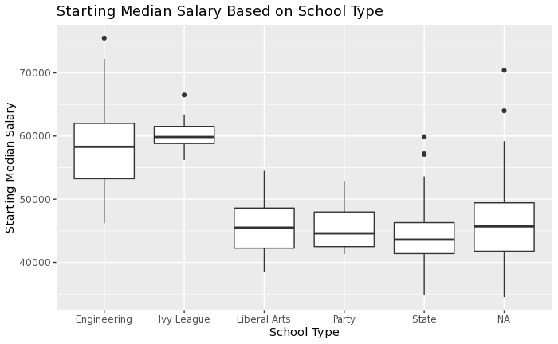

```r
ggplot(SchoolSalaries, aes(x = School_Type, y = Starting_Median_Salary)) +
  geom_boxplot() +
  xlab("School Type") +
  ylab("Starting Median Salary") +
  ggtitle("Starting Median Salary Based on School Type")
```

Now we will observe the top ten schools with the highest starting median salaries. This table will be used to answer the research question.

```r
SchoolSalaries %>%
  select(School_Name, School_Type, Region, Starting_Median_Salary) %>%
  arrange(desc(Starting_Median_Salary)) %>%
  head(10)
```

| School_Name | School_Type | Region | Starting_Median_Salary |
| --- | --- | --- | --- |
| California Institute of Technology (CIT) | Engineering | California | 75500 |
| Massachusetts Institute of Technology (MIT) | Engineering | Northeastern | 72200 |
| Harvey Mudd College | Engineering | California | 71800 |
| Stanford University | NA | California | 70400 |
| Princeton University | Ivy League | Northeastern | 66500 |
| Rice University | NA | Southern | 64000 |
| Harvard University | Ivy League | Northeastern | 63400 |
| Polytechnic University of New York, Brooklyn | Engineering | Northeastern | 62400 |
| Cooper Union | Engineering | Northeastern | 62200 |
| Carnegie Mellon University (CMU) | Engineering | Northeastern | 61800 |

Now we will find the top ten schools with the highest mid-career median salaries.

```r
MidCareerMedianSalaries <-
  SchoolSalaries %>%
  select(School_Name, School_Type, Region, Mid_Career_Median_Salary) %>%
  arrange(desc(Mid_Career_Median_Salary)) %>%
  head(10)
MidCareerMedianSalaries
```

| School_Name | School_Type | Region | Mid_Career_Median_Salary |
| --- | --- | --- | --- |
| Dartmouth College | Ivy League | Northeastern | 134000 |
| Princeton University | Ivy League | Northeastern | 131000 |
| Stanford University | NA | California | 129000 |
| Massachusetts Institute of Technology (MIT) | Engineering | Northeastern | 126000 |
| Yale University | Ivy League | Northeastern | 126000 |
| Harvard University | Ivy League | Northeastern | 124000 |
| California Institute of Technology (CIT) | Engineering | California | 123000 |
| Harvey Mudd College | Engineering | California | 122000 |
| University of Pennsylvania | Ivy League | Northeastern | 120000 |
| University of Notre Dame | NA | Midwestern | 116000 |

At this point we can see that California and NorthEastern schools are in the top ten consistently. We can also see that the top school types are Ivy League and Engineering schools.

Now we will combine these results to find the best school for percent change from starting to mid-career median salary which will show the best school for salary growth over time.

```r
percentChange <-
  SchoolSalaries %>%
  mutate(Percent_Change = ((Mid_Career_Median_Salary - Starting_Median_Salary)/Starting_Median_Salary) * 100) %>%
  select(School_Name, School_Type, Percent_Change) %>%
  arrange(desc(Percent_Change)) %>%
  head(50)
percentChange
```

| School_Name | School_Type | Percent_Change |
| --- | --- | --- |
| Dartmouth College | Ivy League | 131.03448 |
| Davidson College | Liberal Arts | 125.59653 |
| Bowdoin College | Liberal Arts | 122.45322 |
| Mount Holyoke College | NA | 122.16981 |
| Mount Holyoke College | Liberal Arts | 121.93396 |
| Carleton College | Liberal Arts | 116.84211 |
| DePauw University | Liberal Arts | 113.28502 |
| Yale University | Ivy League | 113.19797 |
| DePauw University | NA | 113.04348 |
| University Of Chicago | NA | 111.61049 |

[output cut: 40 more lines]

## Visualizations on Schools and Salaries

This graph shows the progression of percent change from each school and their school type.

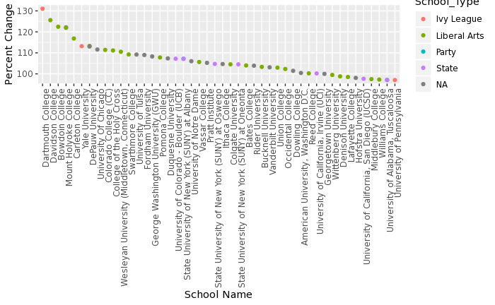

```r
SchoolSalariesGraphic <-
  percentChange%>%
  ggplot(aes(x = reorder(School_Name, -Percent_Change), y = Percent_Change, color = School_Type)) +
  geom_point() +
  xlab("School Name") +
  ylab("Percent Change") +
  theme(axis.text.x = element_text(angle = 90, hjust = 1))
SchoolSalariesGraphic
```

This data frame is calculating a new variable called Above_Avg_MidCareer_Median_Salary which will be used to determine whether the mid career salary is above or below the average of all the schools mid career median salaries.

```r
SchoolSalaries %>% # This code will find the mean for mid career salary
  summarise(mean = sum(Mid_Career_Median_Salary)/339)
```

| mean |
| --- |
| 86076.11 |

```r
MidCareerAvgMedianSalary <-
  SchoolSalaries %>%
  na.omit() %>%
  mutate(Above_Avg_MidCareer_Median_Salary = ifelse(Mid_Career_Median_Salary <= 86076.11, "yes", "no")) # This code uses the mean to indicate an above or below for each school
MidCareerAvgMedianSalary
```

| School_Name | School_Type | Starting_Median_Salary | Mid_Career_Median_Salary | Mid_Career_10th_Percentile_Salary | Mid_Career_25th_Percentile_Salary | Mid_Career_75th_Percentile_Salary | Mid_Career_90th_Percentile_Salary | Difference | Region | Above_Avg_MidCareer_Median_Salary |
| --- | --- | --- | --- | --- | --- | --- | --- | --- | --- | --- |
| Massachusetts Institute of Technology (MIT) | Engineering | 72200 | 126000 | 76800 | 99200 | 168000 | 220000 | 53800 | Northeastern | no |
| Polytechnic University of New York, Brooklyn | Engineering | 62400 | 114000 | 66800 | 94300 | 143000 | 190000 | 51600 | Northeastern | no |
| Worcester Polytechnic Institute (WPI) | Engineering | 61000 | 114000 | 80000 | 91200 | 137000 | 180000 | 53000 | Northeastern | no |
| Carnegie Mellon University (CMU) | Engineering | 61800 | 111000 | 63300 | 80100 | 150000 | 209000 | 49200 | Northeastern | no |
| Rensselaer Polytechnic Institute (RPI) | Engineering | 61100 | 110000 | 71600 | 85500 | 140000 | 182000 | 48900 | Northeastern | no |
| Georgia Institute of Technology | Engineering | 58300 | 106000 | 67200 | 85200 | 137000 | 183000 | 47700 | Southern | no |
| Colorado School of Mines | Engineering | 58100 | 106000 | 62200 | 87900 | 142000 | 201000 | 47900 | Western | no |
| Stevens Institute of Technology | Engineering | 60600 | 105000 | 68700 | 81900 | 138000 | 185000 | 44400 | Northeastern | no |
| Illinois Institute of Technology (IIT) | Engineering | 56000 | 97800 | 56100 | 77400 | 121000 | 165000 | 41800 | Midwestern | no |
| Wentworth Institute of Technology | Engineering | 53000 | 96700 | 55200 | 74000 | 117000 | 153000 | 43700 | Northeastern | no |

[output cut: 213 more lines]

Now we will make a tree to demonstrate the importance of school type and region in determining whether a school will have an above average mid career median salary.

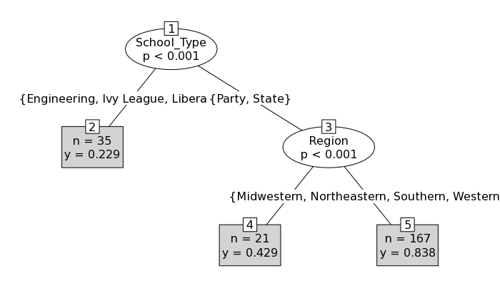

```r
TreeForMidCareer <-
  MidCareerAvgMedianSalary %>%
  select(Above_Avg_MidCareer_Median_Salary, Starting_Median_Salary, Mid_Career_Median_Salary, School_Type, Region)
TreeForMidCareer<-
  TreeForMidCareer %>%
  mutate(School_Type = as.factor(School_Type), Region = as.factor(Region))
mod1 <- party::ctree(Above_Avg_MidCareer_Median_Salary == "yes" ~ School_Type + Region, data = TreeForMidCareer)
plot(mod1, type = "simple")
```

```r
SchoolSalaries %>% # This code will find the mean for starting salary
  summarise(mean = sum(Starting_Median_Salary)/349)
```

| mean |
| --- |
| 46093.41 |

```r
StartingAvgMedianSalary <-
  SchoolSalaries %>%
  mutate(Above_Avg_Starting_Median_Salary = ifelse(Starting_Median_Salary <= 46093.41, "yes", "no"))
StartingAvgMedianSalary
```

| School_Name | School_Type | Starting_Median_Salary | Mid_Career_Median_Salary | Mid_Career_10th_Percentile_Salary | Mid_Career_25th_Percentile_Salary | Mid_Career_75th_Percentile_Salary | Mid_Career_90th_Percentile_Salary | Difference | Region | Above_Avg_Starting_Median_Salary |
| --- | --- | --- | --- | --- | --- | --- | --- | --- | --- | --- |
| Massachusetts Institute of Technology (MIT) | Engineering | 72200 | 126000 | 76800 | 99200 | 168000 | 220000 | 53800 | Northeastern | no |
| California Institute of Technology (CIT) | Engineering | 75500 | 123000 | NA | 104000 | 161000 | NA | 47500 | California | no |
| Harvey Mudd College | Engineering | 71800 | 122000 | NA | 96000 | 180000 | NA | 50200 | California | no |
| Polytechnic University of New York, Brooklyn | Engineering | 62400 | 114000 | 66800 | 94300 | 143000 | 190000 | 51600 | Northeastern | no |
| Cooper Union | Engineering | 62200 | 114000 | NA | 80200 | 142000 | NA | 51800 | Northeastern | no |
| Worcester Polytechnic Institute (WPI) | Engineering | 61000 | 114000 | 80000 | 91200 | 137000 | 180000 | 53000 | Northeastern | no |
| Carnegie Mellon University (CMU) | Engineering | 61800 | 111000 | 63300 | 80100 | 150000 | 209000 | 49200 | Northeastern | no |
| Rensselaer Polytechnic Institute (RPI) | Engineering | 61100 | 110000 | 71600 | 85500 | 140000 | 182000 | 48900 | Northeastern | no |
| Georgia Institute of Technology | Engineering | 58300 | 106000 | 67200 | 85200 | 137000 | 183000 | 47700 | Southern | no |
| Colorado School of Mines | Engineering | 58100 | 106000 | 62200 | 87900 | 142000 | 201000 | 47900 | Western | no |

[output cut: 339 more lines]

Now we will make a tree to demonstrate the importance of school type and region in determining whether a school will have an above average starting median salary.

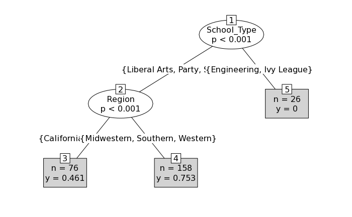

```r
CompleteCases <-
  StartingAvgMedianSalary %>%
  select(Above_Avg_Starting_Median_Salary, Starting_Median_Salary,Mid_Career_Median_Salary,School_Type, Region,School_Name) %>%
  na.omit()
CompleteCases <-
  CompleteCases %>%
  mutate(School_Type = as.factor(School_Type), Region = as.factor(Region), School_Name = as.factor(School_Name))
mod1 <- party::ctree(Above_Avg_Starting_Median_Salary == "yes" ~ School_Type + Region + School_Name, data = CompleteCases)
plot(mod1, type = "simple")
```

### Conclusions on Schools and Salaries

We can conclude that the school to pick if you want the highest starting median salary is California Institute of Technology (CIT) with a salary amount of $75,500, the school to pick if you want the highest mid-career median salary is Dartmouth College with a salary amount of $134,000, and the school to pick if you want the best salary growth over time is DartMouth College with a salary percent growth from starting to mid-career median salary of 131.0345%.

# Second Step in Game Plan: Finding the Majors with the Highest Salaries

We will be using the DegreesThatPayBack dataset to answer this part of the game plan.

First we will look at the top ten majors with the best starting median salary.

```r
head(DegreesThatPayBack)
```

| Undergraduate_Major | Starting_Median_Salary | Mid_Career_Median_Salary | Mid_Career_10th_Percentile_Salary | Mid_Career_25th_Percentile_Salary | Mid_Career_75th_Percentile_Salary | Mid_Career_90th_Percentile_Salary | Percent_Change_From_Starting_To_MidCareer_Salary | Difference |
| --- | --- | --- | --- | --- | --- | --- | --- | --- |
| Accounting | 46000 | 77100 | 42200 | 56100 | 108000 | 152000 | 67.6 | 31100 |
| Aerospace Engineering | 57700 | 101000 | 64300 | 82100 | 127000 | 161000 | 75.0 | 43300 |
| Agriculture | 42600 | 71900 | 36300 | 52100 | 96300 | 150000 | 68.8 | 29300 |
| Anthropology | 36800 | 61500 | 33800 | 45500 | 89300 | 138000 | 67.1 | 24700 |
| Architecture | 41600 | 76800 | 50600 | 62200 | 97000 | 136000 | 84.6 | 35200 |
| Art History | 35800 | 64900 | 28800 | 42200 | 87400 | 125000 | 81.3 | 29100 |

```r
DegreesThatPayBack %>%
  select(Undergraduate_Major, Starting_Median_Salary) %>%
  arrange(desc(Starting_Median_Salary)) %>%
  head(10)
```

| Undergraduate_Major | Starting_Median_Salary |
| --- | --- |
| Physician Assistant | 74300 |
| Chemical Engineering | 63200 |
| Computer Engineering | 61400 |
| Electrical Engineering | 60900 |
| Mechanical Engineering | 57900 |
| Aerospace Engineering | 57700 |
| Industrial Engineering | 57700 |
| Computer Science | 55900 |
| Nursing | 54200 |
| Civil Engineering | 53900 |

From this we can see that the best major for starting median salary is a Physician Assistant.

Now we will look at the top ten majors with the best mid-career median salary.

```r
DegreesThatPayBack %>%
  select(Undergraduate_Major, Mid_Career_Median_Salary) %>%
  arrange(desc(Mid_Career_Median_Salary)) %>%
  head(10)
```

| Undergraduate_Major | Mid_Career_Median_Salary |
| --- | --- |
| Chemical Engineering | 107000 |
| Computer Engineering | 105000 |
| Electrical Engineering | 103000 |
| Aerospace Engineering | 101000 |
| Economics | 98600 |
| Physics | 97300 |
| Computer Science | 95500 |
| Industrial Engineering | 94700 |
| Mechanical Engineering | 93600 |
| Math | 92400 |

From this we can see that the best major for mid-career median salary is Chemical Engineering.

Now we will look at the top ten majors with the best percentage change from starting to mid-career median salary to see which major offers the best growth in salary.

```r
DegreesThatPayBack <-
  DegreesThatPayBack%>%
  select(Undergraduate_Major, Percent_Change_From_Starting_To_MidCareer_Salary) %>%
  arrange(desc(Percent_Change_From_Starting_To_MidCareer_Salary)) %>%
  head(50)
DegreesThatPayBack
```

| Undergraduate_Major | Percent_Change_From_Starting_To_MidCareer_Salary |
| --- | --- |
| Math | 103.5 |
| Philosophy | 103.5 |
| International Relations | 97.8 |
| Economics | 96.8 |
| Marketing | 95.1 |
| Physics | 93.4 |
| Political Science | 91.7 |
| Chemistry | 87.6 |
| Journalism | 87.4 |
| Architecture | 84.6 |

[output cut: 40 more lines]

From this we can see that Math is best major for average salary growth.

## Visualization of Majors and Salaries

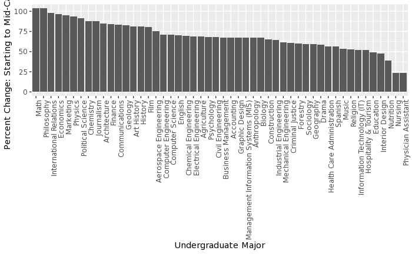

```r
DegreesThatPayBack %>%
  ggplot(aes(x = reorder(Undergraduate_Major, -Percent_Change_From_Starting_To_MidCareer_Salary), y = Percent_Change_From_Starting_To_MidCareer_Salary)) +
  geom_bar(stat = "identity") +
  xlab("Undergraduate Major") +
  ylab("Percent Change: Starting to Mid-Career Salary") +
  theme(axis.text.x = element_text(angle = 90, hjust = 1))
```

### Conclusions of Majors and Salaries

With these results we can conclude that the best major if you want the highest starting median salary is Physician Assistant at $74,300, the best major if you want the highest mid-career median salary is Chemical Engineering at $107,000, and the best major for greatest percent growth from starting to mid-career median salary is Math at 103.5%.

# Third Step in Game Plan: Finding the Occupations with the Highest Salaries and Job Security

We will be using the OccupationSalaries dataset which we found on a website online for the evaluation of this step in the game plan.

First we will extract the table from the website online

```r
web_page<-"https://www.bls.gov/oes/current/oes_nat.htm#00-0000"
ListofTables <-
  web_page %>%
  read_html() %>%
  html_nodes( css = "table") %>%
  html_table(fill = TRUE)
```

Next, we will use data scraping to get the data ready for analysis.

```r
head(ListofTables[[2]])
```

|  | Occupation code | Occupation title (click on the occupation title to view its profile) | Level | Employment | Employment RSE | Employment per 1,000 jobs | Median hourly wage | Mean hourly wage | Annual mean wage | Mean wage RSE |
| --- | --- | --- | --- | --- | --- | --- | --- | --- | --- | --- |
| 1 |  |  |  |  |  | NA |  |  |  |  |
| 2 | 00-0000 | All Occupations | total | 146,875,480 | 0.1% | 1000.000 | $19.14 | $25.72 | $53,490 | 0.1% |
| 3 | 11-0000 | Management Occupations | major | 8,054,120 | 0.2% | 54.836 | $50.80 | $58.88 | $122,480 | 0.1% |
| 4 | 11-1000 | Top Executives | minor | 2,658,440 | 0.3% | 18.100 | $49.63 | $61.09 | $127,070 | 0.2% |
| 5 | 11-1011 | Chief Executives | detail | 205,890 | 0.8% | 1.402 | $88.68 | $93.20 | $193,850 | 0.4% |
| 6 | 11-1021 | General and Operations Managers | detail | 2,400,280 | 0.3% | 16.342 | $48.45 | $59.15 | $123,030 | 0.2% |

```r
OccupationSalaries <- ListofTables[[2]]
OccupationSalaries <- OccupationSalaries %>%
  filter(row_number() > 2) %>%
   rename(Code = `Occupation code`,
          Name =`Occupation title (click on the occupation title to view its profile)`,
          Level = Level,
          Employment = Employment,
          RSE = `Employment RSE`,
          EP1J = `Employment per 1,000 jobs`,
          Median = `Median hourly wage`,
          Mean = `Mean hourly wage`,
          Annual = `Annual mean wage`,
          WRSE = `Mean wage RSE`)
str(OccupationSalaries)
```

```
'data.frame':   1039 obs. of  10 variables:
 $ Code      : chr  "11-0000" "11-1000" "11-1011" "11-1021" ...
 $ Name      : chr  "Management Occupations" "Top Executives" "Chief Executives" "General and Operations Managers" ...
 $ Level     : chr  "major" "minor" "detail" "detail" ...
 $ Employment: chr  "8,054,120" "2,658,440" "205,890" "2,400,280" ...
 $ RSE       : chr  "0.2%" "0.3%" "0.8%" "0.3%" ...
 $ EP1J      : num  54.836 18.1 1.402 16.342 0.356 ...
 $ Median    : chr  "$50.80" "$49.63" "$88.68" "$48.45" ...
 $ Mean      : chr  "$58.88" "$61.09" "$93.20" "$59.15" ...
 $ Annual    : chr  "$122,480" "$127,070" "$193,850" "$123,030" ...
 $ WRSE      : chr  "0.1%" "0.2%" "0.4%" "0.2%" ...
```

```r
OccupationSalaries <-
  OccupationSalaries %>%
  mutate(Employment = gsub(pattern = ',', replacement = '', Employment), RSE = gsub(pattern = '%', replacement = '', RSE), Median = gsub(pattern = '\\$', replacement = '', Median), Mean = gsub(pattern = '\\$', replacement = '', Mean), Annual = gsub(pattern = '\\$|,', replacement = '', Annual), WRSE = gsub(pattern = '%', replacement = '', WRSE))
OccupationSalaries<-
  OccupationSalaries %>%
  mutate(Employment = as.numeric(Employment), RSE = as.numeric(RSE),EP1J = as.numeric(EP1J), Median = as.numeric(Median), Mean = as.numeric(Mean), Annual = as.numeric(Annual), WRSE = as.numeric(WRSE))
```

```
NAs introduced by coercionNAs introduced by coercionNAs introduced by coercion
```

```r
str(OccupationSalaries)
```

```
'data.frame':   1039 obs. of  10 variables:
 $ Code      : chr  "11-0000" "11-1000" "11-1011" "11-1021" ...
 $ Name      : chr  "Management Occupations" "Top Executives" "Chief Executives" "General and Operations Managers" ...
 $ Level     : chr  "major" "minor" "detail" "detail" ...
 $ Employment: num  8054120 2658440 205890 2400280 52280 ...
 $ RSE       : num  0.2 0.3 0.8 0.3 2.2 0.5 3 0.5 0.8 0.6 ...
 $ EP1J      : num  54.836 18.1 1.402 16.342 0.356 ...
 $ Median    : num  50.8 49.6 88.7 48.5 NA ...
 $ Mean      : num  58.9 61.1 93.2 59.1 NA ...
 $ Annual    : num  122480 127070 193850 123030 49440 ...
 $ WRSE      : num  0.1 0.2 0.4 0.2 1.3 0.2 1.3 0.2 0.3 0.3 ...
```

```r
OccupationSalaries <- na.omit(OccupationSalaries)
OccupationSalaries
```

|  | Code | Name | Level | Employment | RSE | EP1J | Median | Mean | Annual | WRSE |
| --- | --- | --- | --- | --- | --- | --- | --- | --- | --- | --- |
| 1 | 11-0000 | Management Occupations | major | 8054120 | 0.2 | 54.836 | 50.80 | 58.88 | 122480 | 0.1 |
| 2 | 11-1000 | Top Executives | minor | 2658440 | 0.3 | 18.100 | 49.63 | 61.09 | 127070 | 0.2 |
| 3 | 11-1011 | Chief Executives | detail | 205890 | 0.8 | 1.402 | 88.68 | 93.20 | 193850 | 0.4 |
| 4 | 11-1021 | General and Operations Managers | detail | 2400280 | 0.3 | 16.342 | 48.45 | 59.15 | 123030 | 0.2 |
| 6 | 11-2000 | Advertising, Marketing, Promotions, Public Relations, and Sales Managers | minor | 770540 | 0.5 | 5.246 | 61.96 | 68.91 | 143330 | 0.2 |
| 7 | 11-2011 | Advertising and Promotions Managers | detail | 25100 | 3.0 | 0.171 | 60.34 | 68.22 | 141890 | 1.3 |
| 8 | 11-2020 | Marketing and Sales Managers | broad | 666280 | 0.5 | 4.536 | 62.84 | 69.55 | 144660 | 0.2 |
| 9 | 11-2021 | Marketing Managers | detail | 263680 | 0.8 | 1.795 | 65.79 | 71.73 | 149200 | 0.3 |
| 10 | 11-2022 | Sales Managers | detail | 402600 | 0.6 | 2.741 | 60.89 | 68.12 | 141690 | 0.3 |
| 11 | 11-2030 | Public Relations and Fundraising Managers | broad | 79160 | 1.3 | 0.539 | 55.86 | 63.77 | 132630 | 0.6 |

[output cut: 938 more lines]

Now we will join the OccupationSalaries dataset to the OccupationProjection dataset so that we can make a full analysis on Occupations that will provide us with data on salaries as well as job openings.

```r
Occupation_Proj_Salary_Base <-
  OccupationsProjection %>%
  rename(Name = Occupation_Name, Code = Occupation_Code) %>%
  full_join(OccupationSalaries)
Occupation_Proj_Salary <- na.omit(Occupation_Proj_Salary_Base)
Occupation_Proj_Salary
```

|  | State_FIPS | Region | Code | Name | Base_Year | Base | Projected_Year | Projection | Percent_Change | Average_Annual_Openings | Level | Employment | RSE | EP1J | Median | Mean | Annual | WRSE |
| --- | --- | --- | --- | --- | --- | --- | --- | --- | --- | --- | --- | --- | --- | --- | --- | --- | --- | --- |
| 1 | 0 | United States | 11-1011 | Chief Executives | 2014 | 343400 | 2024 | 339400 | -1.2 | 5840 | detail | 205890 | 0.8 | 1.402 | 88.68 | 93.20 | 193850 | 0.4 |
| 2 | 0 | United States | 11-1021 | General and Operations Managers | 2014 | 2124100 | 2024 | 2275200 | 7.1 | 68880 | detail | 2400280 | 0.3 | 16.342 | 48.45 | 59.15 | 123030 | 0.2 |
| 4 | 0 | United States | 11-2011 | Advertising and Promotions Managers | 2014 | 31000 | 2024 | 32400 | 4.7 | 1140 | detail | 25100 | 3.0 | 0.171 | 60.34 | 68.22 | 141890 | 1.3 |
| 5 | 0 | United States | 11-2021 | Marketing Managers | 2014 | 194300 | 2024 | 212500 | 9.4 | 6420 | detail | 263680 | 0.8 | 1.795 | 65.79 | 71.73 | 149200 | 0.3 |
| 6 | 0 | United States | 11-2022 | Sales Managers | 2014 | 376300 | 2024 | 395300 | 5.1 | 10800 | detail | 402600 | 0.6 | 2.741 | 60.89 | 68.12 | 141690 | 0.3 |
| 9 | 0 | United States | 11-3021 | Computer and Information Systems Managers | 2014 | 348500 | 2024 | 402200 | 15.4 | 9480 | detail | 433960 | 0.6 | 2.955 | 70.37 | 75.19 | 156390 | 0.3 |
| 10 | 0 | United States | 11-3031 | Financial Managers | 2014 | 555900 | 2024 | 593500 | 6.8 | 16930 | detail | 654790 | 0.6 | 4.458 | 62.45 | 70.93 | 147530 | 0.3 |
| 11 | 0 | United States | 11-3051 | Industrial Production Managers | 2014 | 173400 | 2024 | 167000 | -3.7 | 4910 | detail | 185790 | 0.9 | 1.265 | 50.71 | 55.34 | 115110 | 0.3 |
| 12 | 0 | United States | 11-3061 | Purchasing Managers | 2014 | 73000 | 2024 | 73700 | 1.0 | 1790 | detail | 72100 | 0.8 | 0.491 | 58.23 | 61.73 | 128400 | 0.4 |
| 13 | 0 | United States | 11-3071 | Transportation, Storage, and Distribution Managers | 2014 | 111600 | 2024 | 114100 | 2.2 | 2710 | detail | 132040 | 0.9 | 0.899 | 45.46 | 49.67 | 103320 | 0.4 |

[output cut: 990 more lines]

## Finding Occupations with the Best Job Security

```r
Occupation_Proj_Salary <-
  Occupation_Proj_Salary_Base %>%
  filter(EP1J > 15, Percent_Change > 10,Average_Annual_Openings > 1000) %>%
  arrange(desc(Percent_Change)) %>%
  group_by(Name) %>%
  summarise(Average_Annual_Openings = sum(Average_Annual_Openings)) %>%
  arrange(desc(Average_Annual_Openings)) %>%
  head(50)
Occupation_Proj_Salary
```

| Name | Average_Annual_Openings |
| --- | --- |
| Registered Nurses | 210350 |
| Retail Salespersons | 100590 |
| Waiters and Waitresses | 78410 |
| Customer Service Representatives | 77780 |
| Laborers and Freight, Stock, and Material Movers, Hand | 69290 |
| General and Operations Managers | 53520 |
| Cashiers | 45580 |
| Office Clerks, General | 32370 |

## Visualizations

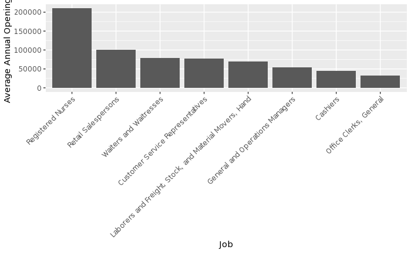

```r
Occupation_Proj_SalaryGraphic1 <-
  Occupation_Proj_Salary %>%
  ggplot(aes(x = reorder(Name, -Average_Annual_Openings), y = Average_Annual_Openings)) +
  geom_bar(stat = "identity") +
  xlab("Job") +
  ylab("Average Annual Openings") +
  theme(axis.text.x = element_text(angle = 45, hjust = 1))
Occupation_Proj_SalaryGraphic1
```

## Finding Jobs with the Highest Salaries

```r
highSalary <-
  Occupation_Proj_Salary_Base %>%
  arrange(desc(Annual)) %>%
  group_by(Name) %>%
  summarise(AnnualSalary = sum(Annual)) %>%
  arrange(desc(AnnualSalary)) %>%
  head(20)
highSalary
```

| Name | AnnualSalary |
| --- | --- |
| Chief Executives | 9304800 |
| Dentists, General | 9269520 |
| Nurse Anesthetists | 8689920 |
| Computer and Information Systems Managers | 8288670 |
| Financial Managers | 7966620 |
| Architectural and Engineering Managers | 7952360 |
| Lawyers | 7700900 |
| Marketing Managers | 7609200 |
| Sales Managers | 7367880 |
| Natural Sciences Managers | 7127050 |

[output cut: 10 more lines]

From the above analysis, it is clear that the jobs with the highest salaries include, Chief Executives, Dentists, Nurse Anesthetists, Computer and Information Systems Managers, Financial Managers and Architectural and Engineering Managers, Lawyers, Marketing Managers, Sales Managers, and Natural Sciences Majors.

## Visualizations

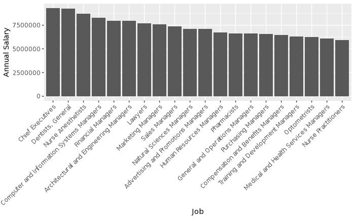

```r
Occupation_Proj_SalaryGraphic2 <-
  highSalary %>%
  ggplot(aes(x = reorder(Name, -AnnualSalary), y = AnnualSalary)) +
  geom_bar(stat = "identity") +
  xlab("Job") +
  ylab("Annual Salary") +
  theme(axis.text.x = element_text(angle = 45, hjust = 1))
Occupation_Proj_SalaryGraphic2
```

# Conclusions for Answering the Research Question